# Cyclistic Case Study

Joseph Brockly-Anderson

2023-08-16

# 1 Project Overview

People Wanting to use the service can either buy single-ride passes, full-day passes, or annual memberships. Those who buy single ride passes or full day passes are referred to as casual riders, Whereas those who purchase annual memberships are referred to as Cyclistic members. This flexibility of Cyclistic’s pricing plans gave it a competitive edge when building the general awareness of the brand and marketing to a broad demographic of potential customers.

Financial analysts at Cyclistic have demonstrated successfully that annual members are much more profitable than casual riders, but why do some people buy single-ride and full-day passes while others purchase annual memberships? Does the length of rides have anything to do with this decision? How can analyzing the past twelve month’s worth of ride-share data help Cyclistic create a more targeted campaign ad to convert casual riders into Cyclistic members?

By asking the right questions, keeping our sights focused on the business task, gathering and preparing relevant data for processing, analyzing it to look for any trends or helpful insights, and using simple maps and charts to visualize our analysis, I hope to tell a story that can inform Cyclistic’s marketing team of potential next steps in their journey to activate annual members.

In order to provide Cyclistic, their marketing team, executive team, and other relevant stakeholders with valuable, accurate insights and data-driven suggestions to convert casual riders into annual members in pursuit of fiscal growth, I’ll be following a programmatic process that includes the following steps:

$$Ask - Prepare - Process - Analyze -
Share - Act$$

Each process will iteratively build on the former, though there will be times we go back to a certain step and repeat the process again and again for more clarity. We’ve already begun asking solid questions: why do some people buy single-ride and full-day passes while others purchase annual memberships? Does the length of rides have anything to do with this decision? How can analyzing the past twelve month’s worth of ride-share data help Cyclistic create a more targeted campaign ad to convert casual riders into Cyclistic members?

# 2 Data Dictionary

The original dataset had 13 columns, but in order to perform a more thorough analysis it was necessary to utilize the information contained within it to produce additional columns that would display information about things like ride distance, speed, length, and type of day. All of the attributes in the finalized clean dataset are registered in the data dictionary below.

| Variable | Meaning |
| --- | --- |
| ride_id | A signifier used to uniquely identify each bike ride |
| rideable_type | Whether the bike ridden was electric, classic, or docked |
| started_at | The date and time the trip was started |
| ended_at | The date and time the trip was ended |
| start_station_name | The name of the station where the trip began |
| start_station_id | A unique identifier given to the station where the trip began |
| end_station_name | The name of the station where the trip ended |
| end_station_id | A unique identifier given to the station where the trip ended |
| start_lat | The latitude of the starting location |
| start_lng | The longitude of the starting location |
| end_lat | The latitude of the ending location |
| end_lng | The longitude of the ending location |
| member_casual | Whether a rider is casual or an annual member |
| ride_length | A calculated column containing the ride length in minutes |
| is_weekday | Whether the ride started on a weekday (TRUE) or weekend (FALSE) |
| computed_distance | The Haversine distance between trip start and end locations |
| cluster | What cluster a starting point belongs to |

# 3 Preparing the Data

## 3.1 Calling up the Required Packages

First, we’re going to call in the `tidyverse` collection for it’s `readr`, `dplyr`, `tidyr`, and `ggplot2` packages. We’ll also call up several other packages that will helps us at varying moments throughout our analysis.

```r
library(tidyverse) # an avowed collection of data analytics packages such as as `readr`
# which helps us pull in data, `dplyr` which helps us manipulate data, `tidyr` which helps us clean data, and `ggplot2` which helps us visualize data
library(lubridate) # helps us systematize dates and times
library(data.table) # helps us stack our data
library(validate) # this helps us validate the data
library(assertr) # helps us validate the data
library(knitr)# helps us create aesthetically pleasing tables
library(ggmap) # helps us pull in maps for visualization
library(dbscan) # enables us to perform density-based spatial cluster
```

## 3.3 Combining the Datasets into One Manageable Data Frame

In order to clean and analyze this data, we first need to combine all of the rows in each of the 12 data sets into one data frame with 13 columns that correspond to the original data sets’ variable types. We can do this with the `list()` and `rbindlist()` functions.

```r
# combining each month's data source into a list
trips_df <-
  list(df202208, df202209, df202210,
       df202211, df202212, df202301,
       df202302, df202303, df202304,
       df202305, df202306, df202307)

# stacking the rows into a single data frame
df_dirty <- rbindlist(trips_df)

## The code below is specifically for cleaning up our environment once we've pulled all
## the data in.
rm(list = ls(pattern = "^df202")) # this removes all data objects beginning with "df202"
rm(trips_df) # keeping our environment clean
```

# 4 Obtaining a Sample

In order to make the process of cleaning this data more efficient and less computationally burdensome, we will take a sample size of 666 observations, determined using the sample size calculator at [this website](https://www.surveysystem.com/sscalc.htm). Based on our population, this sample size will give us a confidence level of 99% with a confidence interval of 5.

```r
# setting a seed for reproducibility
set.seed(888)

sample_size <- 666

df_sample_dirty <- df_dirty[sample(nrow(df_dirty), sample_size), ]
```

# 5 Getting Acquainted with the Data

Now that we’ve successfully gathered and sampled our data, this section will help us understand its structure, how many rows and columns our data frame contains, the names of our variables, what they measure, and how these data types are codified. The data frame contains 666 observations (trips taken on a Cyclistic bicycle within the period between August 2022 and July 2023) with 13 separate attributes. As seen below, there are seven string (character) variables, four float (double) variables, and two date/time (POSIXct) variables. A table of summary statistics can be seen below as well.

```r
# pulling up the column names
colnames(df_sample_dirty)
```

```
##  [1] "ride_id"            "rideable_type"      "started_at"
##  [4] "ended_at"           "start_station_name" "start_station_id"
##  [7] "end_station_name"   "end_station_id"     "start_lat"
## [10] "start_lng"          "end_lat"            "end_lng"
## [13] "member_casual"
```

```r
# glancing at the data types and beginning values
glimpse(df_sample_dirty)
```

```
## Rows: 666
## Columns: 13
## $ ride_id            <chr> "6DBE185CA213103F", "EA4D25B1A74DFDCA", "6720C8EADE…
## $ rideable_type      <chr> "electric_bike", "electric_bike", "electric_bike", …
## $ started_at         <dttm> 2022-08-14 13:46:03, 2023-03-23 06:53:25, 2022-08-…
## $ ended_at           <dttm> 2022-08-14 13:46:04, 2023-03-23 07:09:06, 2022-08-…
## $ start_station_name <chr> "Lincoln Park Conservatory", "Broadway & Barry Ave"…
## $ start_station_id   <chr> "LP-", "13137", "13300", "TA1309000002", "623", "TA…
## $ end_station_name   <chr> NA, "Elizabeth St & Randolph St", "Burnham Harbor",…
## $ end_station_id     <chr> NA, "23001", "15545", "TA1307000130", "TA1307000128…
## $ start_lat          <dbl> 41.92415, 41.93758, 41.88099, 41.87785, 41.87277, 4…
## $ start_lng          <dbl> -87.63591, -87.64400, -87.61673, -87.62408, -87.623…
## $ end_lat            <dbl> 41.92000, 41.88000, 41.85741, 41.87174, 41.89897, 4…
## $ end_lng            <dbl> -87.64000, -87.66000, -87.61379, -87.65103, -87.629…
## $ member_casual      <chr> "casual", "member", "casual", "casual", "member", "…
```

```r
# viewing the first rows
kable(head(df_sample_dirty, 5),
      col.names = c("ID",
                    "Type",
                    "Start Time",
                    "End Time",
                    "Start Station",
                    "Start ID",
                    "End Station",
                    "End ID",
                    "Start Lat",
                    "Start Lng",
                    "End Lat",
                    "End Lng",
                    "Customer")
      )
```

| ID | Type | Start Time | End Time | Start Station | Start ID | End Station | End ID | Start Lat | Start Lng | End Lat | End Lng | Customer |
| --- | --- | --- | --- | --- | --- | --- | --- | --- | --- | --- | --- | --- |
| 6DBE185CA213103F | electric_bike | 2022-08-14 13:46:03 | 2022-08-14 13:46:04 | Lincoln Park Conservatory | LP- | NA | NA | 41.92415 | -87.63591 | 41.92000 | -87.64000 | casual |
| EA4D25B1A74DFDCA | electric_bike | 2023-03-23 06:53:25 | 2023-03-23 07:09:06 | Broadway & Barry Ave | 13137 | Elizabeth St & Randolph St | 23001 | 41.93758 | -87.64400 | 41.88000 | -87.66000 | member |
| 6720C8EADEFFDBF0 | electric_bike | 2022-08-27 14:32:47 | 2022-08-27 14:51:05 | DuSable Lake Shore Dr & Monroe St | 13300 | Burnham Harbor | 15545 | 41.88099 | -87.61673 | 41.85741 | -87.61379 | casual |
| F2F65886BB45C040 | classic_bike | 2022-08-06 20:46:03 | 2022-08-06 21:15:34 | Michigan Ave & Jackson Blvd | TA1309000002 | Morgan St & Polk St | TA1307000130 | 41.87785 | -87.62408 | 41.87174 | -87.65103 | casual |
| 8CE93693980C2772 | classic_bike | 2022-11-30 17:28:01 | 2022-11-30 17:51:47 | Michigan Ave & 8th St | 623 | Dearborn Pkwy & Delaware Pl | TA1307000128 | 41.87277 | -87.62398 | 41.89897 | -87.62991 | member |

```r
# getting summary statistics
summary(df_sample_dirty)
```

```
##    ride_id          rideable_type        started_at
##  Length:666         Length:666         Min.   :2022-08-01 18:09:52.00
##  Class :character   Class :character   1st Qu.:2022-09-24 12:13:38.00
##  Mode  :character   Mode  :character   Median :2023-01-20 19:12:55.00
##                                        Mean   :2023-01-28 18:03:51.58
##                                        3rd Qu.:2023-06-02 21:54:57.00
##                                        Max.   :2023-07-31 19:07:31.00
##
##     ended_at                      start_station_name start_station_id
##  Min.   :2022-08-01 18:14:39.00   Length:666         Length:666
##  1st Qu.:2022-09-24 12:22:14.75   Class :character   Class :character
##  Median :2023-01-20 19:22:21.50   Mode  :character   Mode  :character
##  Mean   :2023-01-28 18:23:46.73
##  3rd Qu.:2023-06-02 21:57:46.25
##  Max.   :2023-07-31 19:26:18.00
##
##  end_station_name   end_station_id       start_lat       start_lng
##  Length:666         Length:666         Min.   :41.75   Min.   :-87.78
##  Class :character   Class :character   1st Qu.:41.88   1st Qu.:-87.66
##  Mode  :character   Mode  :character   Median :41.90   Median :-87.64
##                                        Mean   :41.90   Mean   :-87.65
##                                        3rd Qu.:41.93   3rd Qu.:-87.63
##                                        Max.   :42.06   Max.   :-87.55
##
##     end_lat         end_lng       member_casual
##  Min.   :41.71   Min.   :-87.77   Length:666
##  1st Qu.:41.88   1st Qu.:-87.66   Class :character
##  Median :41.90   Median :-87.65   Mode  :character
##  Mean   :41.90   Mean   :-87.65
##  3rd Qu.:41.93   3rd Qu.:-87.63
##  Max.   :42.05   Max.   :-87.55
##  NA's   :1       NA's   :1
```

# 6 Cleaning the Data

## 6.1 Checking for Duplicates

In order to perform an accurate analysis, we need to process the data to make sure it contains no incorrect, duplicate, or unaccounted for observations. We also need to manage any gaps in the information and make sure the formatting and data types remain consistent across our data sources. To do this, we’ll first check for duplicate observations with the `duplicated()` function.

```r
# every observation should be unique
sum(duplicated(df_dirty))
```

```
## [1] 0
```

```r
# there should be three types of bike
n_distinct(df_sample_dirty$rideable_type)
```

```
## [1] 3
```

```r
# there should be two types of rider
uniqueN(df_sample_dirty$member_casual)
```

```
## [1] 2
```

```r
# there should be as many unique ride IDs as there are total observations
n_distinct(df_sample_dirty$ride_id)
```

```
## [1] 666
```

## 6.2 Checking for Null Values

```r
sum(is.na(df_sample_dirty))
```

```
## [1] 402
```

```r
sum(is.na(df_sample_dirty$ride_id))
```

```
## [1] 0
```

```r
sum(is.na(df_sample_dirty$rideable_type))
```

```
## [1] 0
```

```r
sum(is.na(df_sample_dirty$started_at))
```

```
## [1] 0
```

```r
sum(is.na(df_sample_dirty$ended_at))
```

```
## [1] 0
```

```r
sum(is.na(df_sample_dirty$start_station_name))
```

```
## [1] 99
```

```r
sum(is.na(df_sample_dirty$start_station_id))
```

```
## [1] 99
```

```r
sum(is.na(df_sample_dirty$end_station_name))
```

```
## [1] 101
```

```r
sum(is.na(df_sample_dirty$end_station_id))
```

```
## [1] 101
```

```r
sum(is.na(df_sample_dirty$start_lat))
```

```
## [1] 0
```

```r
sum(is.na(df_sample_dirty$start_lng))
```

```
## [1] 0
```

```r
sum(is.na(df_sample_dirty$end_lat))
```

```
## [1] 1
```

```r
sum(is.na(df_sample_dirty$end_lng))
```

```
## [1] 1
```

```r
sum(is.na(df_sample_dirty$member_casual))
```

```
## [1] 0
```

What could be causing this lack of data? Will these null values jeopardize our analysis or are they sufficiently random? After further investigation, it has come to light that Motivate LLC ‘s bike fleet is outfitted with on-board GPS trackers to pinpoint their location from within the entire service area. The fleet is technically designated as a “dockless” one (though they do manage a small sub-fleet of “docked” bikes. From this information, we can conclude why null values appear in the start station name, start station ID, end station name, and end station ID columns: neither casual riders nor annual members need to pick up or drop off bikes at designated stations. This makes dealing with these null values significantly simpler in our analysis, but what about the missing value in bike trips’ ending locations?

It seems reasonable to believe that this missing values could be coming from:

- human error on part of the database gathering systems in use at Cyclistic
- technical issues with GPS tracking caused by electronic malfunctions
- user-related error emerging from a failure to properly conclude bike trips

We’ll go ahead and check the starting and ending coordinates to verify if they are correlated for non-missing values. There is a moderate correlation between starting latitude and ending latitude, but nothing has pointed us to a belief this null value was systematically incorporated into the data. From this, we’re going to assume that this null value’s presence is sufficiently random enough to avoid complications in our analysis, though further investigation may reveal the necessity to impute the value in the future. With this in mind, we’ll go ahead and ignore the observation which accounts for ~0.15% of our observation total.

## 6.3 Removing Leading/Trailing Spaces

Leading and trailing spaces in a character string can frustrate our attempts as analysts to capture that data and manipulate it in our analysis. We need some way to find and remove leading and trailing spaces within the data frame that we’re working with. This is a solid practice to safeguard the quality of our data before analysis, streamline our troubleshooting process, and avoid any setbacks later on. To do this, we can use the `stringr` package. NOTE: To prevent the lengthening of our final document when knitted to PDF, I’ve gone ahead and hidden the bulk of this code, though my process can be identified within the first chunk.

```r
# the `str_trim()` function only works on string data
df_sample_dirty$ride_id <-
  str_trim(df_sample_dirty$ride_id,
           "left")
df_sample_dirty$ride_id <-
  str_trim(df_sample_dirty$ride_id,
           "right")
```

## 6.4 Ensuring Proper Formats

As a further measure of data processing, we’ll make sure our columns are structured correctly. This is an invaluable part of keeping an organized project and will save us time troubleshooting should we encounter bugs in our code during analysis and visualization.

### 6.4.1 Datetime

```r
## the POSIXct stores date/time values
is.POSIXct(df_sample_dirty$started_at)
```

```
## [1] TRUE
```

```r
is.POSIXct(df_sample_dirty$ended_at)
```

```
## [1] TRUE
```

### 6.4.2 Strings

```r
is.character(df_sample_dirty$ride_id)
```

```
## [1] TRUE
```

```r
is.character(df_sample_dirty$rideable_type)
```

```
## [1] TRUE
```

```r
is.character(df_sample_dirty$start_station_name)
```

```
## [1] TRUE
```

```r
is.character(df_sample_dirty$start_station_id)
```

```
## [1] TRUE
```

```r
is.character(df_sample_dirty$end_station_name)
```

```
## [1] TRUE
```

```r
is.character(df_sample_dirty$end_station_id)
```

```
## [1] TRUE
```

```r
is.character(df_sample_dirty$member_casual)
```

```
## [1] TRUE
```

### 6.4.3 Numeric

```r
# a "double" atomic vector is commonly referred to as a "float" in other languages and programs
is.double(df_sample_dirty$start_lat)
```

```
## [1] TRUE
```

```r
is.double(df_sample_dirty$start_lng)
```

```
## [1] TRUE
```

```r
is.double(df_sample_dirty$end_lat)
```

```
## [1] TRUE
```

```r
is.double(df_sample_dirty$end_lng)
```

```
## [1] TRUE
```

## 6.5 Data Validation

We need to validate our dataset to ensure that it contains the range of values that we assume actually exists within the data set.

```r
## validating `ride_id`
# setting the number of characters to `v_ride_id`
valid_ride_id <- nchar(
  df_sample_dirty$ride_id
  )

sum(
  valid_ride_id == 16
  ) # the number of TRUEs should match the number of total observations (666)
```

```
## [1] 666
```

```r
## validating `rideable_type` and `member_casual`
# creating vectors of allowed values
valid_rideable <- c("electric_bike", "classic_bike", "docked_bike")

valid_m_c <- c("member", "casual")


# returning an error if any cell doesn't contain appropriate values
stopifnot(all(df_sample_dirty$rideable_type %in% valid_rideable))

stopifnot(all(df_sample_dirty$member_casual %in% valid_m_c))


## validating `started_at` and `ended_at`
# determining maximum and minimum values
max(df_sample_dirty$started_at)
```

```
## [1] "2023-07-31 19:07:31 UTC"
```

```r
min(df_sample_dirty$started_at)
```

```
## [1] "2022-08-01 18:09:52 UTC"
```

```r
max(df_sample_dirty$ended_at)
```

```
## [1] "2023-07-31 19:26:18 UTC"
```

```r
min(df_sample_dirty$started_at)
```

```
## [1] "2022-08-01 18:09:52 UTC"
```

```r
sum(df_sample_dirty$started_at < "2022-07-01 00:00:00")
```

```
## [1] 0
```

```r
sum(df_sample_dirty$ended_at > "2023-08-31 11:59:59")
```

```
## [1] 0
```

```r
# defining the date/time range
start_date <- as.POSIXct("2022-07-01 00:00:00")
end_date <- as.POSIXct("2023-08-31 11:59:59")

# filtering out unnecessary observations
df_sample_dirty <- subset(df_sample_dirty,
                      started_at >= start_date &
                        started_at <= end_date &
                        ended_at >= start_date &
                        ended_at <= end_date)
```

## 6.6 Presenting the Cleaned Data

So far, we have called up the required packages, pulled in the data relevant to providing insights in favor of our business task with Cyclistic, merged the data sets together into one data frame, obtained a subset of that data based on an appropriate sample size, made sure that no duplicates exist, explored the context of present null values, removed leading and trailing spaces in character columns, ensured that the attributes are properly formatted, and verified that our data exists within the boundaries we expect. Our data is now clean and ready for a thorough analysis. We’ve printed a small table of the clean data below to get a feel for what we’re now working with, but we’ve left out the ID attributes for ease of readability.

```r
# renaming our data frame from ease of use
df_clean <- df_sample_dirty


# cleaning up our environment
rm(df_dirty, df_sample_dirty)


# selecting desired columns to present in a summary table
df_clean_selected <- df_clean %>%
  select("rideable_type",
         "started_at",
         "ended_at",
         "start_station_name",
         "end_station_name",
         "start_lat",
         "start_lng",
         "end_lat",
         "end_lng",
         "member_casual")

# shortening "Type" values for readability
df_clean_selected$rideable_type <- recode(df_clean_selected$rideable_type,
       "electric_bike" = "Electric",
       "docked_bike" = "Docked",
       "classic_bike" = "Classic")

kable(head(df_clean_selected, 5),
      col.names = c("Type",
                    "Start Time",
                    "End Time",
                    "Start Station",
                    "End Station",
                    "Start Lat",
                    "Start Lng",
                    "End Lat",
                    "End Lng",
                    "Customer"),
      caption = "Cyclistic Bike Trip Data",
      digits = 2)
```

Cyclistic Bike Trip Data

| Type | Start Time | End Time | Start Station | End Station | Start Lat | Start Lng | End Lat | End Lng | Customer |
| --- | --- | --- | --- | --- | --- | --- | --- | --- | --- |
| Electric | 2022-08-14 13:46:03 | 2022-08-14 13:46:04 | Lincoln Park Conservatory | NA | 41.92 | -87.64 | 41.92 | -87.64 | casual |
| Electric | 2023-03-23 06:53:25 | 2023-03-23 07:09:06 | Broadway & Barry Ave | Elizabeth St & Randolph St | 41.94 | -87.64 | 41.88 | -87.66 | member |
| Electric | 2022-08-27 14:32:47 | 2022-08-27 14:51:05 | DuSable Lake Shore Dr & Monroe St | Burnham Harbor | 41.88 | -87.62 | 41.86 | -87.61 | casual |
| Classic | 2022-08-06 20:46:03 | 2022-08-06 21:15:34 | Michigan Ave & Jackson Blvd | Morgan St & Polk St | 41.88 | -87.62 | 41.87 | -87.65 | casual |
| Classic | 2022-11-30 17:28:01 | 2022-11-30 17:51:47 | Michigan Ave & 8th St | Dearborn Pkwy & Delaware Pl | 41.87 | -87.62 | 41.90 | -87.63 | member |

# 7 Analyzing and Visualizing the Data

Now that the data has been thoroughly cleaned, we can use it to generate data driven insights that will help Cyclistic’s marketing team convert casual riders into annual members. Why do some people prefer buying day passes and single ride passes while others prefer purchasing annual memberships?

### 7.0.1 Bike Preferences

Casual riders and annual members both prefer to ride electric bikes, but annual members do still enjoy riding classic bicycles. This could be because either bike works for the purpose their using the service for. Hardly anyone from either group rides docked bikes, which means that any advertising shouldn’t focus on them for conversion potential.

```r
bike_pref <- df_clean %>%
  group_by(member_casual, rideable_type) %>%
  summarise(pref_count = n()) %>%
  arrange(member_casual, desc(pref_count)) %>%
  slice(1) %>%
  ungroup()

kable(head(bike_pref),
      col.names = c("Customer Type", "Preferred Bike", "Preference Count"))
```

| Customer Type | Preferred Bike | Preference Count |
| --- | --- | --- |
| casual | electric_bike | 151 |
| member | electric_bike | 224 |

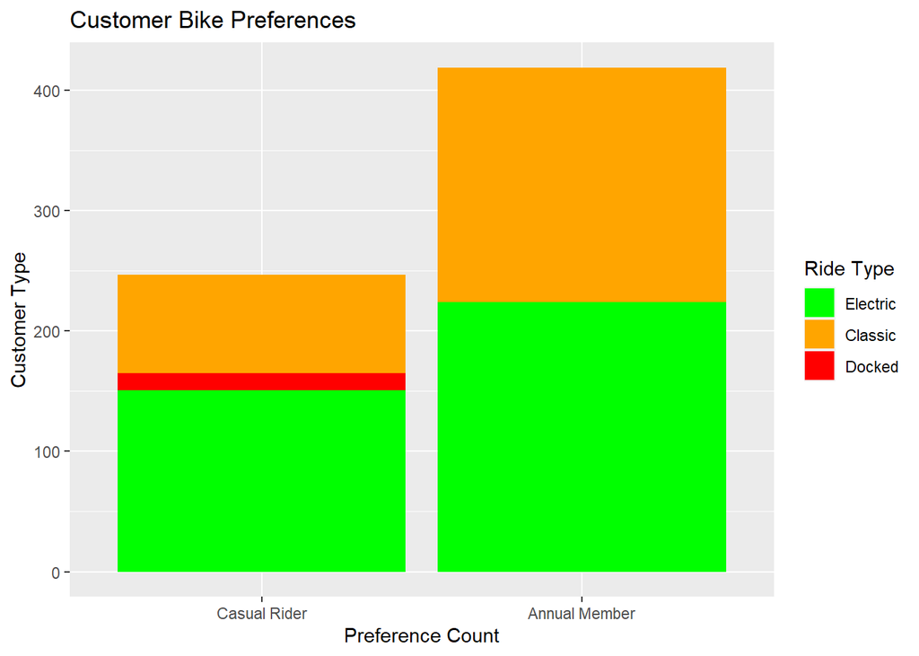

```r
# visualizing preferences
ggplot(df_clean, aes(x = member_casual, fill = rideable_type)) +
  geom_bar() +
  labs(title = "Customer Bike Preferences",
       x = "Preference Count",
       y = "Customer Type",
       fill = "Ride Type") +
  scale_x_discrete(labels = c(casual = "Casual Rider",
                              member = "Annual Member")) +
  scale_fill_manual(values = c("green",
                               "orange",
                               "red"),
                    breaks = c("electric_bike",
                               "classic_bike",
                               "docked_bike"),
                    labels = c("Electric",
                               "Classic",
                               "Docked"))
```

# 8 Trip Duration Analysis

Does the length of bike rides have anything to do with this decision? In our analysis we encountered two anomalous bike trips that lasted in excess of 15 hours and while it is technically possible for this data to be accurate, we’ve filtered the observations out of the following graph to get a better visual handle on the spread of our data and the distinctness of our averages (denoted by green lines). As one can see, casual members take bike trips that are over twice as long as those taken by annual members. Is this because members don’t feel as obligated to get the most out of the single ride since they can ride as many times as they’d like for a flat rate? A further analysis will help us speculate potential answers.

```r
# calculating ride length in minutes
df_clean <- df_clean %>%
  mutate(ride_length = as.numeric(difftime(ended_at, started_at, units = "mins")))

df_clean$ride_length <- df_clean$ride_length %>%
  round(digits = 2)

# grouping data by customer type
average_ride_length <- df_clean %>%
  group_by(member_casual) %>%
  summarise(avg_ride_length = mean(ride_length, na.rm = TRUE))

kable(head(average_ride_length),
      col.names = c("Customer Type", "Average Length (min)"),
      digits = 1)
```

| Customer Type | Average Length (min) |
| --- | --- |
| casual | 32.2 |
| member | 12.7 |

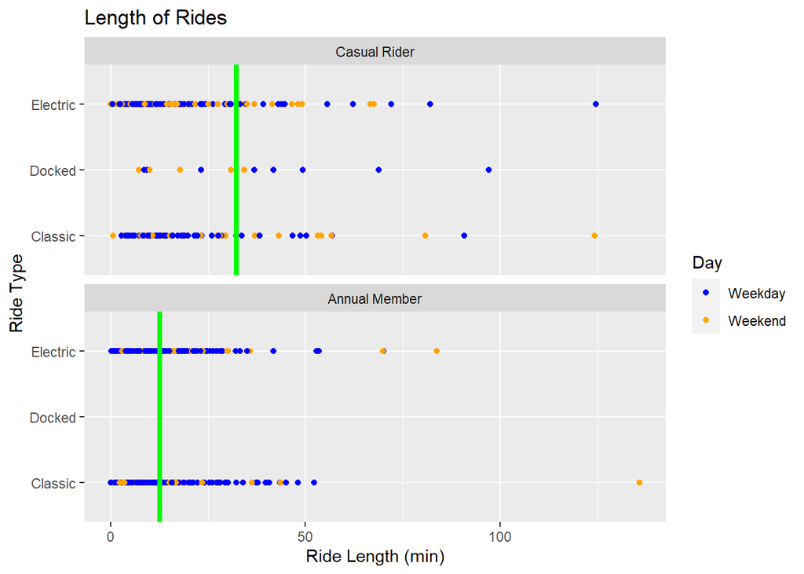

```r
# adding a day of the week column
df_clean <- df_clean %>%
  mutate(is_weekday = weekdays(started_at) %in%
           c("Monday",
             "Tuesday",
             "Wednesday",
             "Thursday",
             "Friday"))

# visualizing ride length
df_clean %>%
  filter(ride_length < 500) %>%
  ggplot(aes(x = ride_length,
             y = rideable_type,
             color = (is_weekday))) +
  geom_point() +
  geom_vline(data = subset(
    average_ride_length, member_casual == "casual"),
             aes(xintercept = avg_ride_length),
             linetype = "solid",
             color = "green",
             linewidth = 1.5) +
  geom_vline(data = subset(average_ride_length, member_casual == "member"),
             aes(xintercept = avg_ride_length),
             linetype = "solid",
             color="green",
             linewidth = 1.5) +
  facet_wrap(~ member_casual,
             nrow = 2,
             labeller =
               labeller(member_casual =
                                   c("casual" = "Casual Rider", "member" = "Annual Member"))) +
  labs(title = "Length of Rides",
       x = "Ride Length (min)",
       y = "Ride Type",
       color = "Day") +
  scale_y_discrete(labels = c("electric_bike" = "Electric",
                              "classic_bike" = "Classic",
                              "docked_bike" = "Docked")) +
  scale_color_manual(values = c("blue", "orange"),
                     breaks = c("TRUE", "FALSE"),
                     labels = c("Weekday", "Weekend"))
```

# 9 Trip Frequency Analysis

```r
# calculating the number of rides taken by each customer type
ride_counts <- df_clean %>%
  group_by(member_casual) %>%
  summarise(ride_count = n()) %>%
  mutate(average_rides_perm = ride_count / as.numeric(((max(df_clean$started_at) - min(df_clean$started_at) + 1) / 30)))

# rides taken by customer by weekday/weekend
weekday_rides <- df_clean %>%
  filter(is_weekday) %>%
  group_by(member_casual) %>%
  summarise(weekday_ride_count = n())

weekend_rides <- df_clean %>%
  filter(!is_weekday) %>%
  group_by(member_casual) %>%
  summarise(weekend_ride_count = n())

# merging the new data frames
ride_counts <- ride_counts %>%
  left_join(weekend_rides, by = "member_casual") %>%
  left_join(weekday_rides, by = "member_casual")

# calculating weekday trip percentages
weekday_ride_percentage <- ride_counts %>%
  group_by(member_casual) %>%
  summarise(
    weekday_percentage = sum(weekday_ride_count) / sum(weekday_ride_count + weekend_ride_count) * 100
  )

# joining weekday trip percentages
ride_counts <- ride_counts %>%
  left_join(weekday_ride_percentage,
            by = "member_casual")

# making a table with bike counts
kable(head(ride_counts),
      col.names = c("Customer", "Rides Taken", "Rides Taken Per Month", "Weekday Trips", "Weekend Trips", "Weekday %"),
      caption = "Trip Frequency",
      digits = 1)
```

Trip Frequency

| Customer | Rides Taken | Rides Taken Per Month | Weekday Trips | Weekend Trips | Weekday % |
| --- | --- | --- | --- | --- | --- |
| casual | 247 | 20.3 | 82 | 165 | 66.8 |
| member | 419 | 34.4 | 87 | 332 | 79.2 |

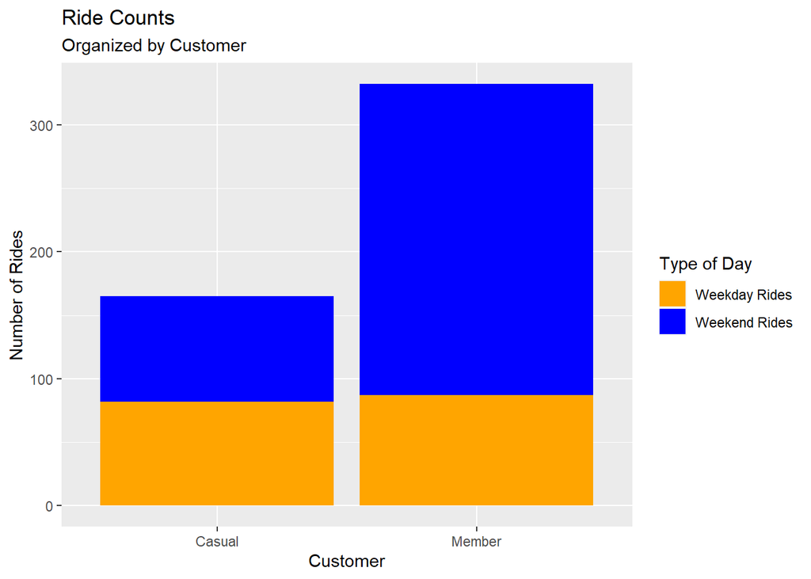

```r
# plotting the data
ggplot(ride_counts, aes(x = member_casual)) +
  geom_bar(aes(y = weekday_ride_count,
               fill = "Weekend Rides"),
           stat = "identity") +
  geom_bar(aes(y = weekend_ride_count,
               fill = "Weekday Rides"),
           stat = "identity",
           position = "dodge") +
  labs(title = "Ride Counts",
       subtitle = "Organized by Customer",
       x = "Customer",
       y = "Number of Rides") +
  scale_fill_manual(
    values = c("Weekend Rides" = "blue",
               "Weekday Rides" = "orange"),
    name = "Type of Day") +
  scale_x_discrete(labels = c("casual" = "Casual",
                   "member" = "Member"))
```

# 10 Trip Time & Seasonality Analysis

When do these two groups start their bike rides? When do they end them? Are there any seasonal trends we can look at to help us answer these questions? With a quick look at the visualizations below, We can see that both casual riders and annual members start and end their rides later in the day. Despite a surge in ridership from annual members during June, what’s important to notice are that the frequencies of bike rides for both groups of customers peaks around the beginning of September. This is a seasonal hotspot for advertising activity.

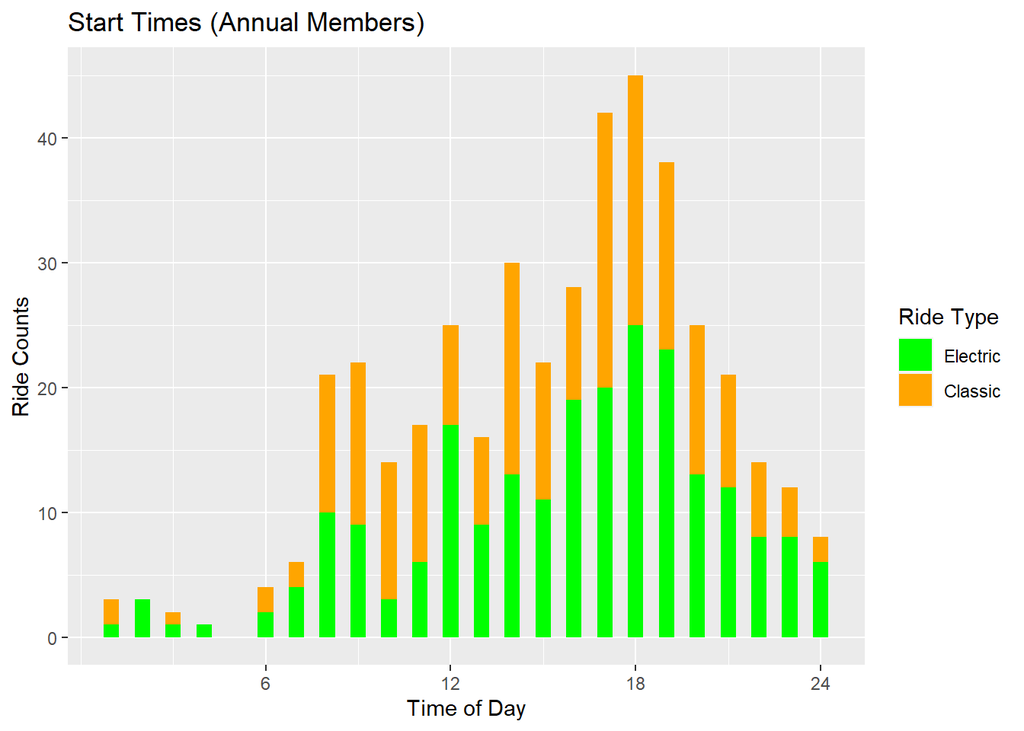

```r
## annual members
member_df <- df_clean %>%
  filter(member_casual == "member")

# start time histogram
ggplot(member_df,
       aes(x = hour(started_at),
           fill = rideable_type)) +
  geom_histogram(binwidth = 0.5) +
  labs(
    title = "Start Times (Annual Members)",
    x = "Time of Day",
    y = "Ride Counts",
    fill = "Ride Type") +
  scale_fill_manual(values = c("green",
                               "orange",
                               "red"),
                    breaks = c("electric_bike",
                               "classic_bike",
                               "docked_bike"),
                    labels = c("Electric",
                               "Classic",
                               "Docked")) +
  scale_x_continuous(breaks = seq(5, 23, by = 6),
                   labels = seq(6, 24, by = 6)
                   )
```

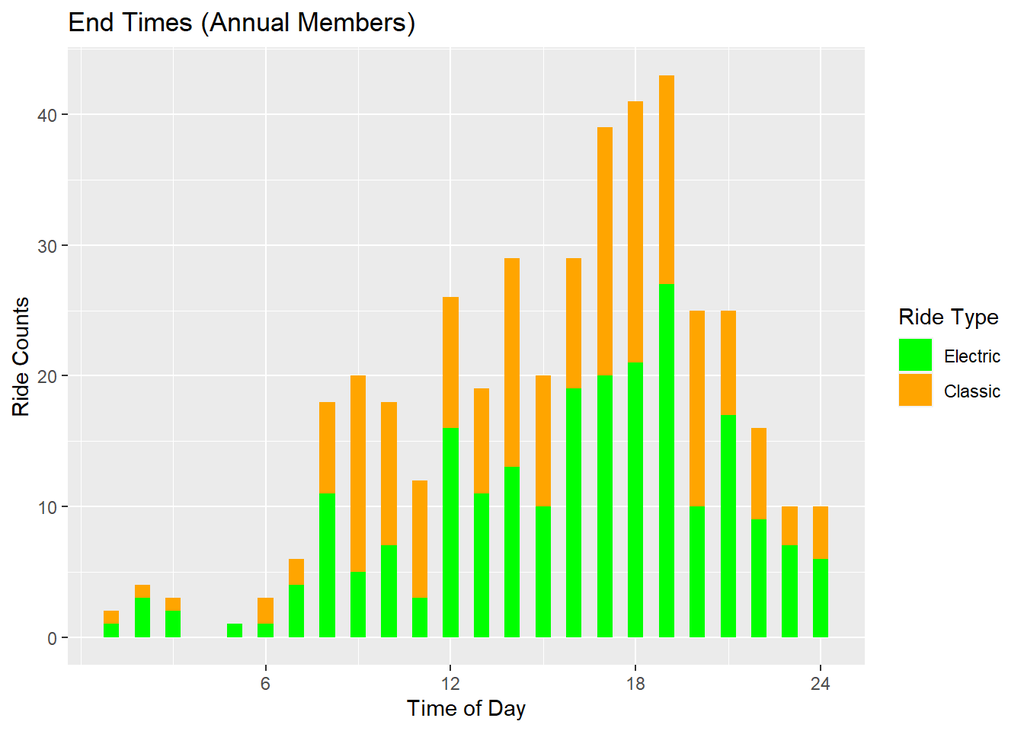

```r
# end time histogram
ggplot(member_df,
       aes(x = hour(ended_at),
           fill = rideable_type)) +
  geom_histogram(binwidth = 0.5) +
  labs(
    title = "End Times (Annual Members)",
    x = "Time of Day",
    y = "Ride Counts",
    fill = "Ride Type") +
  scale_fill_manual(values = c("green",
                               "orange",
                               "red"),
                    breaks = c("electric_bike",
                               "classic_bike",
                               "docked_bike"),
                    labels = c("Electric",
                               "Classic",
                               "Docked")) +
  scale_x_continuous(breaks = seq(5, 23, by = 6),
                   labels = seq(6, 24, by = 6)
                   )
```

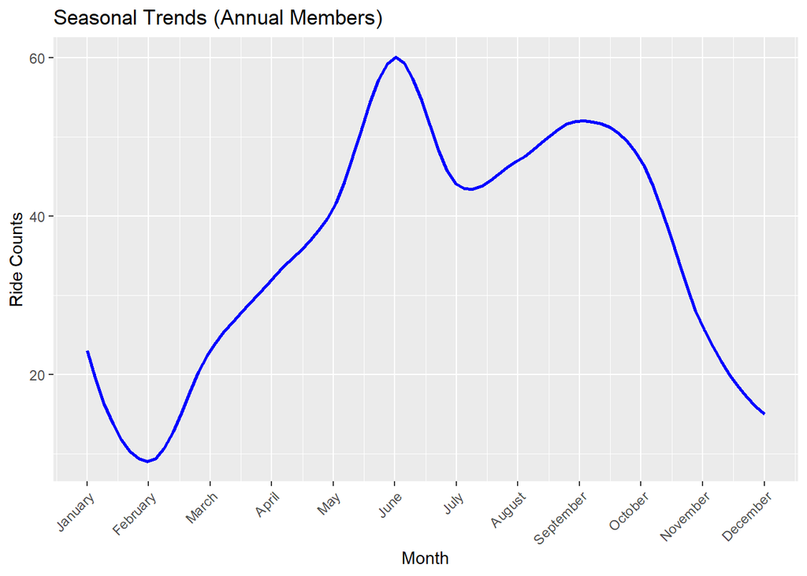

```r
# seasonal trends
member_df %>%
  mutate(month = month(started_at)) %>%
  group_by(month) %>%
  summarise(ride_count = n()) %>%
  ggplot(aes(x = month, y = ride_count)) +
  geom_smooth(method = "loess",
              span = 0.35,
              se = FALSE,
              color = "blue",
              linewidth = 1) +
  labs(title = "Seasonal Trends (Annual Members)",
       x = "Month",
       y = "Ride Counts") +
  scale_x_continuous(breaks = c(1, 2, 3, 4, 5, 6,
                                7, 8, 9, 10, 11, 12),
                     labels = c("January","February","March",
                                "April","May","June","July",
                                "August","September","October",
                                "November","December")) +
  theme(axis.text.x = element_text(angle = 45,
                                   hjust = 1)
        )
```

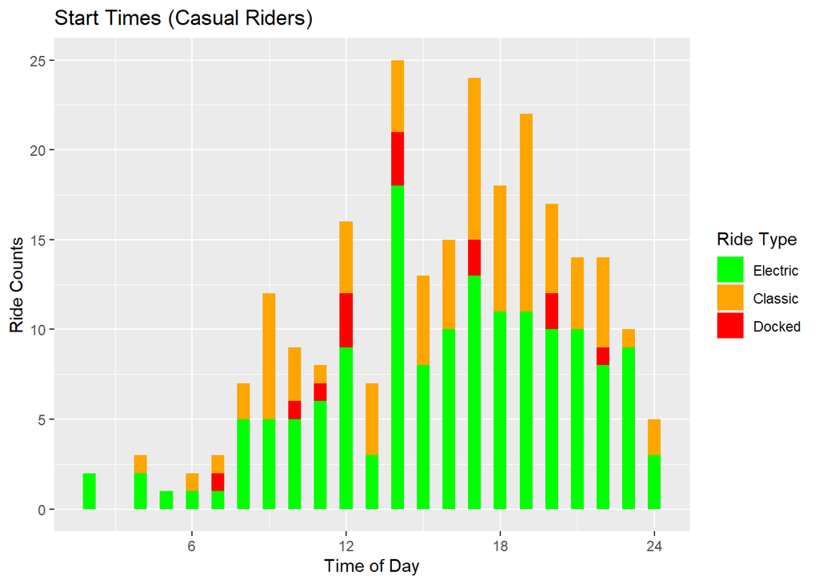

```r
## casual riders
casual_df <- df_clean %>%
  filter(member_casual == "casual")

# start time histogram
ggplot(casual_df,
       aes(x = hour(started_at),
           fill = rideable_type)) +
  geom_histogram(binwidth = 0.5) +
  labs(
    title = "Start Times (Casual Riders)",
    x = "Time of Day",
    y = "Ride Counts",
    fill = "Ride Type") +
  scale_fill_manual(values = c("green",
                               "orange",
                               "red"),
                    breaks = c("electric_bike",
                               "classic_bike",
                               "docked_bike"),
                    labels = c("Electric",
                               "Classic",
                               "Docked")) +
  scale_x_continuous(breaks = seq(5, 23, by = 6),
                   labels = seq(6, 24, by = 6)
                   )
```

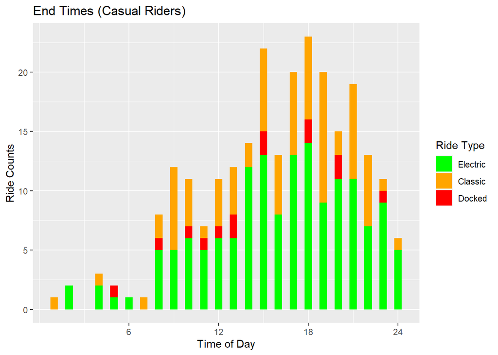

```r
# end time histogram
ggplot(casual_df,
       aes(x = as.POSIXct(hour(ended_at)),
           fill = rideable_type)) +
  geom_histogram(binwidth = 0.5) +
  labs(
    title = "End Times (Casual Riders)",
    x = "Time of Day",
    y = "Ride Counts",
    fill = "Ride Type") +
  scale_fill_manual(values = c("green",
                               "orange",
                               "red"),
                    breaks = c("electric_bike",
                               "classic_bike",
                               "docked_bike"),
                    labels = c("Electric",
                               "Classic",
                               "Docked")) +
  scale_x_continuous(breaks = seq(5, 23, by = 6),
                   labels = seq(6, 24, by = 6)
                   )
```

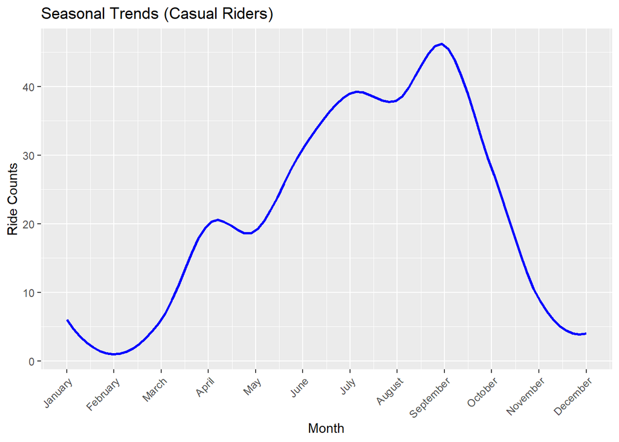

```r
# seasonal trends
casual_df %>%
  mutate(month = month(started_at)) %>%
  group_by(month) %>%
  summarise(ride_count = n()) %>%
  ggplot(aes(x = month, y = ride_count)) +
  geom_smooth(method = "loess",
              span = 0.35,
              se = FALSE,
              color = "blue",
              linewidth = 1) +
  labs(title = "Seasonal Trends (Casual Riders)",
       x = "Month",
       y = "Ride Counts") +
  scale_x_continuous(breaks = c(1, 2, 3, 4, 5, 6,
                                7, 8, 9, 10, 11, 12),
                     labels = c("January","February","March",
                                "April","May","June","July",
                                "August","September","October",
                                "November","December")) +
  theme(axis.text.x = element_text(angle = 45,
                                   hjust = 1)
        )
```

# 11 Trip Location Analysis

Our data shows that the top 10 most popular starting stations across both groups of customers are all in and around the university district of Chicago, Hyde Park. There is also a dense concentration of starting locations for both casual riders and annual members along the Central Lakefront. These locations offer enticing potential for advertising campaigns.

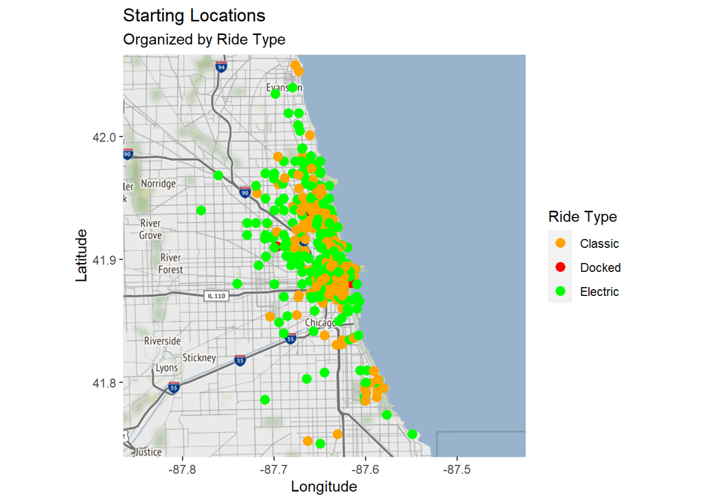

```r
## building a function to calculate Haversine distance
haversine_distance <- function(lat1, lon1, lat2, lon2){
  # converting degrees to radians
  lat1 <- as.numeric(lat1) * pi / 180
  lon1 <- as.numeric(lon1) * pi / 180
  lat2 <- as.numeric(lat2) * pi / 180
  lon2 <- as.numeric(lon2) * pi / 180

  # Haversine formula
  a <- sin((lat2 - lat1)/2)^2 + cos(lat1) * cos(lat2) *   sin((lon2 - lon1)/2)^2
  distance <- 2 * 3958.756 * asin(sqrt(a)) # Earth's radius in miles

  return(distance)
}

# applying the function
df_clean$computed_distance <-
  mapply(haversine_distance,
         df_clean$start_lat,
         df_clean$start_lng,
         df_clean$end_lat,
         df_clean$end_lng)

# average distance by customer type
average_trip_distance <- df_clean %>%
  filter(!is.na(computed_distance)) %>%
  group_by(member_casual) %>%
  summarise(avg_distance = mean(computed_distance))


## finding popular stations
popular_starts <- df_clean %>%
  filter(!is.na(start_station_name)) %>%
  group_by(start_station_name) %>%
  summarise(
    count = n(),
    start_lat = mean(start_lat),
    start_lng = mean(start_lng)
  ) %>%
  arrange(-count) %>%
  top_n(10)

popular_ends <- df_clean %>%
  filter(!is.na(end_station_name)) %>%
  group_by(end_station_name) %>%
  summarise(count = n()) %>%
  arrange(-count) %>%
  top_n(10)


## finding popular routes
popular_routes <- df_clean %>%
  filter(
    !is.na(start_station_name) & !is.na(end_station_name)
    ) %>%
  group_by(start_station_name,
  end_station_name) %>%
  summarise(count = n()) %>%
  arrange(-count) %>%
  top_n(10)


## mapping start stations
# finding the center of our map
total_mean_lat <- mean(df_clean$start_lat)
total_mean_lng <- mean(df_clean$start_lng)

chicago_map <- get_map(
  location = c(
    lon = total_mean_lng,
    lat = total_mean_lat),
  zoom = 11,
  source = "stamen")

# plotting our map
ggmap(chicago_map) +
  geom_point(
    data = df_clean,
    aes(
      x = start_lng,
      y = start_lat,
      color = rideable_type),
    size = 3) +
  labs(title = "Starting Locations",
       subtitle = "Organized by Ride Type",
       x = "Longitude",
       y = "Latitude") +
  scale_color_manual(name = "Ride Type",
                     values = c("electric_bike" = "green",
                                "classic_bike" = "orange",
                                "docked_bike" = "red"),
                     labels = c("Classic",
                                "Docked",
                                "Electric"),
               )
```

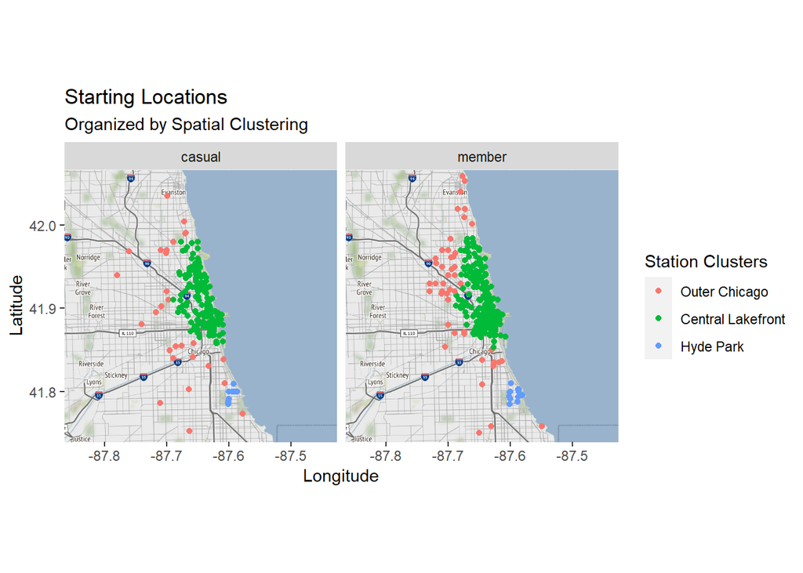

```r
## density-based spatial clustering
coordinates <- df_clean[, c("start_lng", "start_lat")]

clusters <- dbscan(coordinates, eps = 0.01, minPts = 10)

df_clean$cluster <- clusters$cluster

df_clean$member_casual <- as.factor(df_clean$member_casual)

cluster_labels <- c("Outer Chicago",
                    "Central Lakefront",
                    "Hyde Park")

# plotting clusters by color and customer
ggmap(chicago_map) +
  geom_point(
    data = df_clean,
    aes(
      x = start_lng,
      y = start_lat,
      color = as.factor(cluster))) +
  labs(title = "Starting Locations",
       subtitle = "Organized by Spatial Clustering",
       x = "Longitude",
       y = "Latitude") +
  scale_color_discrete(name = "Station Clusters",
                       labels = cluster_labels) +
  facet_wrap(~ member_casual)
```

[figure not shown]

```r
## mapping popular start stations
# finding the center of our map
mean_lat <- mean(popular_starts$start_lat)
mean_lng <- mean(popular_starts$start_lng)

s_chicago_map <- get_map(location = c(lon = mean_lng, lat = mean_lat), zoom = 13, source = "stamen")

# plotting our map
ggmap(s_chicago_map) +
  geom_point(
    data = popular_starts,
    aes(
      x = start_lng,
      y = start_lat,
      size = count
    ),
    color = "red") +
  scale_size(
    name = "Number of Rides",
    range = c(3, 9),
    breaks = 1:3) +
  labs(title = "Top 10 Popular Start Stations",
       x = "Longitude",
       y = "Latitude")
```

# 12 Ride Speeds

The same kinds of considerations need to be taken when looking at average speeds between the two groups. When we preformed the calculation to find each group’s average speed, several dozen observations returned a values of less than 1 mph because they traveled for a time but not a distance (they had returned to the place they began). One observation of a casual rider stated their ride speed was over 1000 miles per hour. Other than these, nothing was out of the ordinary, so we filtered these outliers. To be sure, these speeds are not entirely representative of individual rides, but their averages were calculated with the same metrics and so are still reliable.

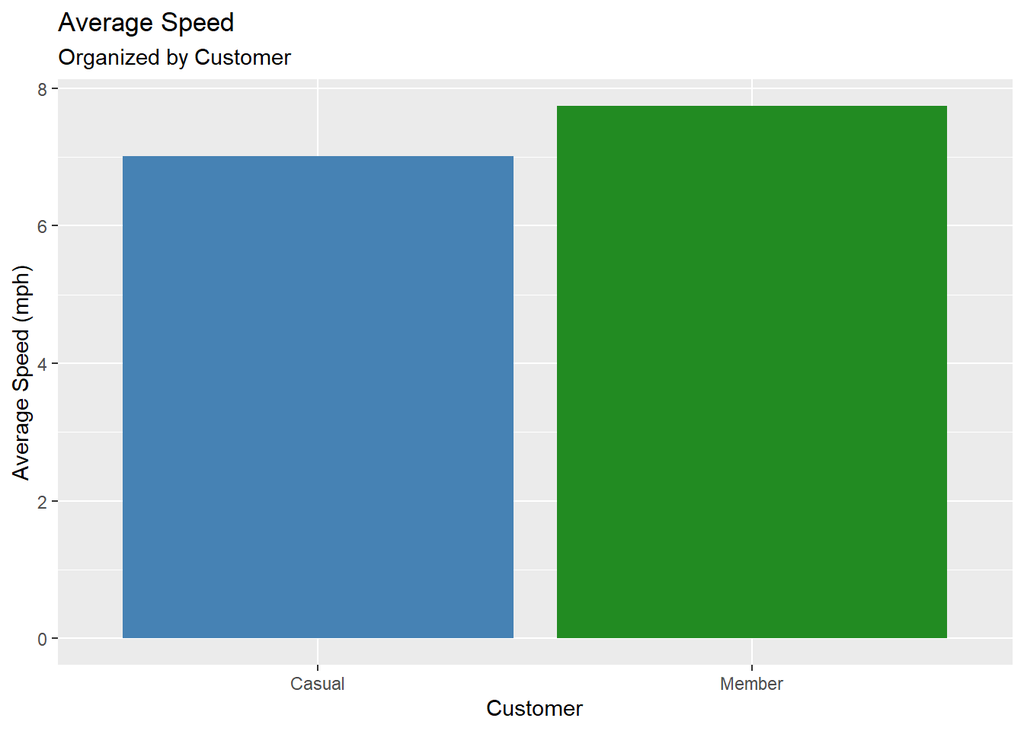

```r
# calculating average trip speeds
df_clean <- df_clean %>%
  mutate(ride_length_hours = ride_length / 60)
df_clean <- df_clean %>%
  mutate(speed_mph = computed_distance / ride_length_hours)

# rounding column data
df_clean$ride_length_hours <- df_clean$ride_length_hours %>%
  round(digits = 2)
df_clean$speed_mph <- df_clean$speed_mph %>%
  round(digits = 2)

# verifying column data
max_speeds <- df_clean %>%
  arrange(-speed_mph)
min_speeds <- df_clean %>%
  arrange(speed_mph)

# calculating averages
average_speeds <- df_clean %>%
  filter(speed_mph > 1 & speed_mph < 25) %>%
  group_by(member_casual) %>%
  summarize(average_speed_mph = mean(speed_mph, na.rm = TRUE))

average_speed_by_bike <- df_clean %>%
  filter(speed_mph > 1 & speed_mph < 25) %>%
  group_by(rideable_type) %>%
  summarize(avg_speed_by_bike_mph = mean(speed_mph, na.rm = TRUE))

# graphing average speeds
ggplot(average_speeds, aes(x = member_casual, y = average_speed_mph, fill = member_casual)) +
  geom_col() +
  labs(title = "Average Speed",
       subtitle = "Organized by Customer",
       x = "Customer",
       y = "Average Speed (mph)") +
  scale_fill_manual(values = c("casual" = "steelblue",
                               "member" = "forestgreen")) +
  guides(fill = FALSE) +
  scale_x_discrete(labels = c("casual" = "Casual",
                              "member" = "Member"))
```

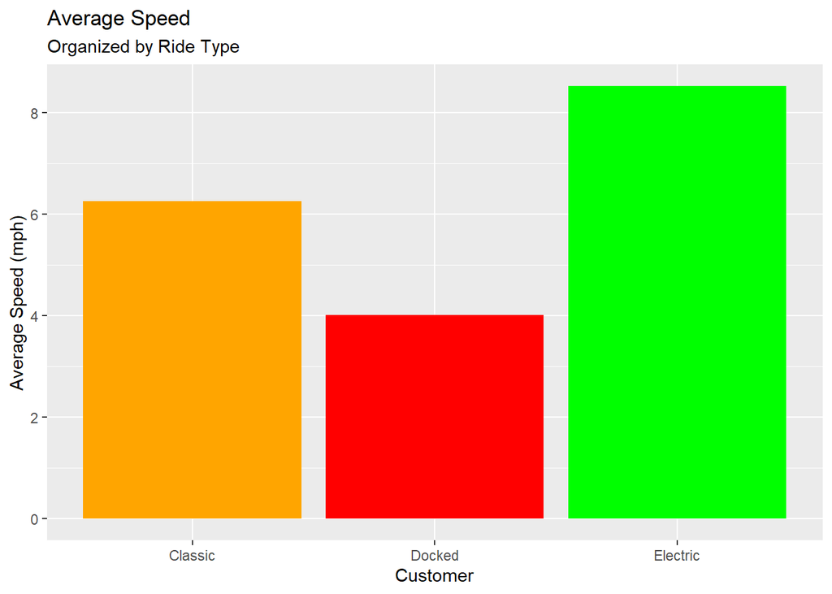

```r
# graphing by type of bike
ggplot(average_speed_by_bike,
       aes(x = rideable_type,
           y = avg_speed_by_bike_mph,
           fill = rideable_type)) +
  geom_col() +
  labs(title = "Average Speed",
       subtitle = "Organized by Ride Type",
       x = "Customer",
       y = "Average Speed (mph)") +
  scale_fill_manual(values = c("classic_bike" = "orange",
                               "docked_bike" = "red",
                               "electric_bike" = "green")) +
  guides(fill = FALSE) +
  scale_x_discrete(labels = c("classic_bike" = "Classic", "docked_bike" = "Docked", "electric_bike" = "Electric"))
```

# 13 Final Analysis and Recommendations

Through our analysis and visualization of Cyclistic’s bike share data, we have shown that although annual members have a slight preference for electric bikes, they ride electric and classic bikes at nearly the same frequency. It doesn’t not matter to them which bike they ride, they just like the freedom of a dockless fleet. With the average speed by group in mind, designing ad campaigns that emphasize the plurality of choices offered to those in need while highlighting the speed that electric bikes can deliver can help Cyclistic to appeal to those casual riders who may prefer similar benefits.

Bike riding for both groups tends to pick up in frequency outside of regular working hours, though we see a jump in casual rides around lunch time. Seasonally, members typically ride the most leading up to and peaking in June, with a slight decline as temperatures rise in July, kicking the pace back up in August and September. Casual riders also peak in September, a fortunate overlap that should not be overlooked by the marketing team. Running advertising campaigns during these peak times may capture the attention of casual riders seeking the benefits of a full membership. Because ridership falls flat across both groups almost entirely in February, Cyclistic should avoid wasting advertising and other resources promoting a campaign during the winter months.

Both annual members and casual riders alike typically begin their journeys along the Central Lakefront, the region in Chicago containing some of the most populated and popular destinations. Moreover, The top 10 most popular starting locations are all grouped in and around Hyde Park, the university district. These two locations represent prime real estate for advertising campaigns focused on converting casual riders into annual members and may present opportunities for cross-promotional negotiations with local businesses.

Based on the information that we’ve gathered through our analysis, here are six simple recommendations for the Cyclistic marketing team:

- Focus on promotional content that highlights the versatility of Cyclistic’s bike fleet with a nod to speed capacity of electric bikes
- Develop a marketing campaign that demonstrates the savings of a Cyclistic membership for frequent riders compared to annual costs of gas, car maintenance, time in traffic, tax rides, etc.
- Promote the convenience and freedom of using Cyclistic’s dockless bike fleet with an annual membership
- Launch seasonal advertising that targets casual riders during September
- Increase the availability of Cyclistic’s bike fleet along Central Lakefront and around Hyde Park
- Reach out to local businesses in these areas with cross-promotional offers

# 14 Conclusion

By conducting a thorough analysis of Cyclistic’s bike share data in the past year, I have developed a package of recommendations that will increase the revenue for Cyclistic and the positive user experience of their customers.Taking these suggestions seriously will increase the conversion rate between casual riders and annual members and open up a doorway towards increasing sales and inflating membership subscriptions. To further analyze how the marketing team can drive these conversions, Cyclistic could look towards gathering more types of data about their customers. A simple way to do this would be through customer surveys, which would enable Cyclistic to understand rider motivations and offer specialized feedback, or capturing demographic information, payment methods, website interaction, weather conditions, and more. A treasure trove of data analysis could take place if we aggregated all of this information together and I’m thrilled to get the chance to continue.

# 15 Acknowledgmements

Dowle, Matt, and Arun Srinivasan. 2023. *Data.table: Extension of ‘Data.frame‘*. https://CRAN.R-project.org/package=data.table.

Fischetti, Tony. 2022. *Assertr: Assertive Programming for r Analysis Pipelines*. https://CRAN.R-project.org/package=assertr.

Grolemund, Garrett, and Hadley Wickham. 2011. “Dates and Times Made Easy with lubridate.” *Journal of Statistical Software* 40 (3): 1–25. https://www.jstatsoft.org/v40/i03/.

Hahsler, Michael, Matthew Piekenbrock, and Derek Doran. 2019. “dbscan: Fast Density-Based Clustering with R.” *Journal of Statistical Software* 91 (1): 1–30. https://doi.org/10.18637/jss.v091.i01.

Kahle, David, and Hadley Wickham. 2013. “Ggmap: Spatial Visualization with Ggplot2.” *The R Journal* 5 (1): 144–61. https://journal.r-project.org/archive/2013-1/kahle-wickham.pdf.

van der Loo, Mark P. J., and Edwin de Jonge. 2021. “Data Validation Infrastructure for R.” *Journal of Statistical Software* 97 (10): 1–31. https://doi.org/10.18637/jss.v097.i10.

Wickham, Hadley, Mara Averick, Jennifer Bryan, Winston Chang, Lucy D’Agostino McGowan, Romain François, Garrett Grolemund, et al. 2019. “Welcome to the tidyverse.” *Journal of Open Source Software* 4 (43): 1686. https://doi.org/10.21105/joss.01686.

Xie, Yihui. 2014. “Knitr: A Comprehensive Tool for Reproducible Research in R.” In *Implementing Reproducible Computational Research*, edited by Victoria Stodden, Friedrich Leisch, and Roger D. Peng. Chapman; Hall/CRC.